# PARCIAL # 2

Julian Velandia

2025-06-13

# 1 Desarrollo

## 1.1 Primer punto

*Enunciado 1:* Una población de electores contiene 40% de republicanos y 60% de demócratas. Se publica que 30% de los republicanos y 70% de los demócratas están a favor de un tema de elección.

```
## [1] 0.42
```

```
## [1] 0.28
```

```
## [1] 0.18
```

[output not shown]

## 1.2 Segundo punto

*Enunciado 2:* De los artículos producidos diariamente por una fábrica, 40% provienen de la línea I y 60% de la línea II. La línea I tiene un porcentaje de 8% de piezas defectuosas en tanto que la II tiene un porcentaje de 10%. a. Elabore un dataframe con la información del problema. b. Si se escoge al azar una pieza de la producción diaria, encuentre la probabilidad de que no esté defectuosa.

*Solución:*

```
##         . Defectuoso NoDefectuoso Total
## 1 Linea 1      0.032        0.368   0.4
## 2 Linea 2      0.060        0.540   0.6
## 3   Total      0.092        0.908   1.0
```

## 1.3 Tercer punto

*Enunciado 3:* 3. Cuando el departamento de salud examinó pozos privados en un condado en busca de dos impurezas que comúnmente se hallan en el agua potable, se encontró que 20% de los pozos no tenían ninguna impureza, 40% tenían la impureza A y 50% tenían la impureza B. (Obviamente, algunos tenían ambas impurezas.) Si un pozo de los existentes en el condado se escoge al azar, a. Encuentre la distribución de probabilidad para X, el número de impurezas halladas en el pozo y grafíquela. b. Encuentre la función de distribución acumulativa para x y con base en ella encuentre F(1)

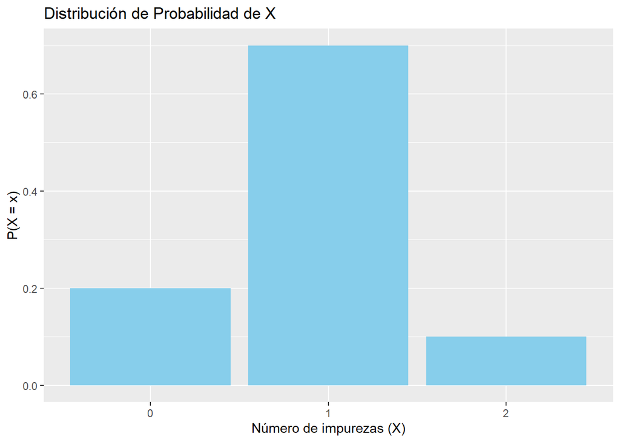

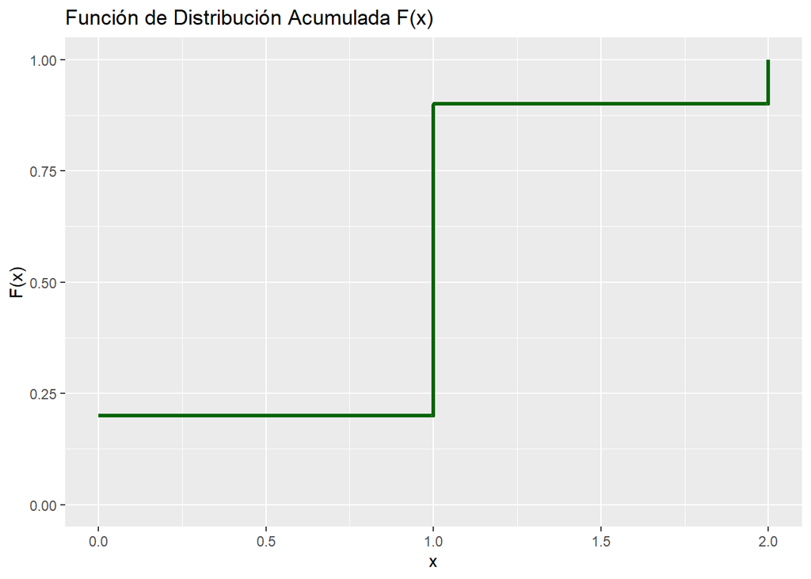

## 1.4 Cuarto punto

*Enunciado 4:* Una gasolinera opera dos bombas, cada una de las cuales puede bombear hasta 10,000 galones de gasolina en un mes. La cantidad total de gasolina bombeada en un mes es una variable aleatoria X (medida en 10,000 galones) con una función de densidad de probabilidad dada abajo.

1. Dibuje la función de densidad. b Encuentre F(x).
2. Encuentre P(0.5 ≤ X ≤ 1.2).

*Solución:*

```
## a) Grafica de la función
```

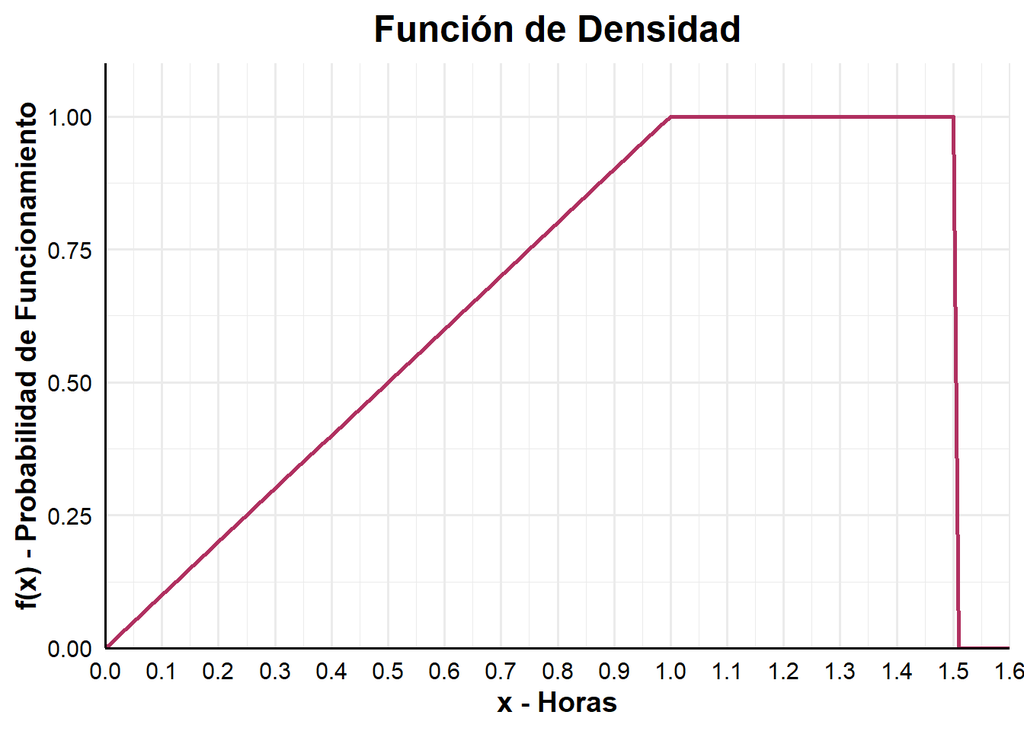

```
## [1] 1
```

```
## b) La función de a hasta x de F(x) es:
```

[output not shown]

```
## [1] 0.575
```

```
## c) La probabilidad P(0.5 ≤ X ≤ 1.2) es: 0.575
```

## 1.5 Quinto punto

[output not shown]

[figure not shown]

## 1.6 Sexto punto

*Enunciado 6:* La proporción de tiempo X en la que un robot industrial está en operación durante una semana de 40 horas es una variable aleatoria con función de densidad dada abajo a. Encuentre F(x) y dibújela. b. Para el robot motivo de estudio, la utilidad Y para una semana está dada por Y = 200X – 60. Encuentre V(Y)

[output not shown]

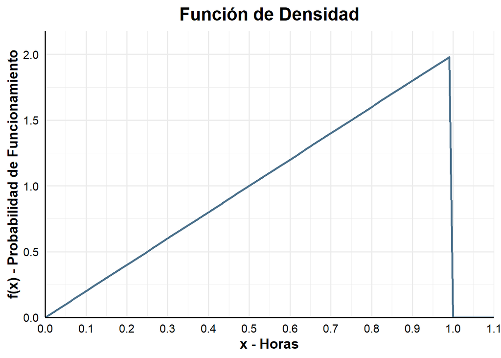

```
## b) Para el robot motivo de estudio, la utilidad Y para una semana está dada por Y = 200X – 60. Encuentre V(Y)
```

```
## [1] 36.66667
```

```
## [1] 30
```

[output not shown]